# Is Money The Real Key To Success in Football?

Faisal Abdulwahab

2026-04-14

# Introduction

Football (soccer) is a sport that has increasingly become shaped by financial power. As transfer fees and club expenditures continue to rise, a central question has emerged: has football become a game that can simply be bought? Some argue that success is largely determined by financial strength, pointing to the largest clubs that consistently invest heavily in elite players and achieve strong results. However, football, like any complex system, is influenced by more than a single factor.

While money is often seen as the primary driver of success, other elements play a critical role. These include the competitiveness of a club’s domestic league, the strength of football culture within a country, how effectively the money is spent, the stability of a squad, and the historical advantage some clubs have. Together, these factors suggest that spending alone may not fully explain success at the highest level.

This project investigates the extent to which money influences success in modern football, using continental trophies as the primary measure of achievement. The analysis focuses on a 5 season period from 2020/21 to 2024/25, comparing financial investment in players with performance outcomes across the 50 top-spending clubs. In this analysis, success is defined as winning at least one continental trophy over the observed time period.

While there is a clear relationship between high spending and success, I believe that this relationship is not absolute. Some clubs invest heavily and fail to win major trophies, while others achieve success through more balanced approaches. Therefore, while money is an important component of success in modern football, it is not sufficient on its own. Instead, success is better understood as the result of how financial resources interact with factors such as recruitment strategy, squad stability, and historical advantage.

## Vizualization 1: The Relationship Between Expenditure and Success

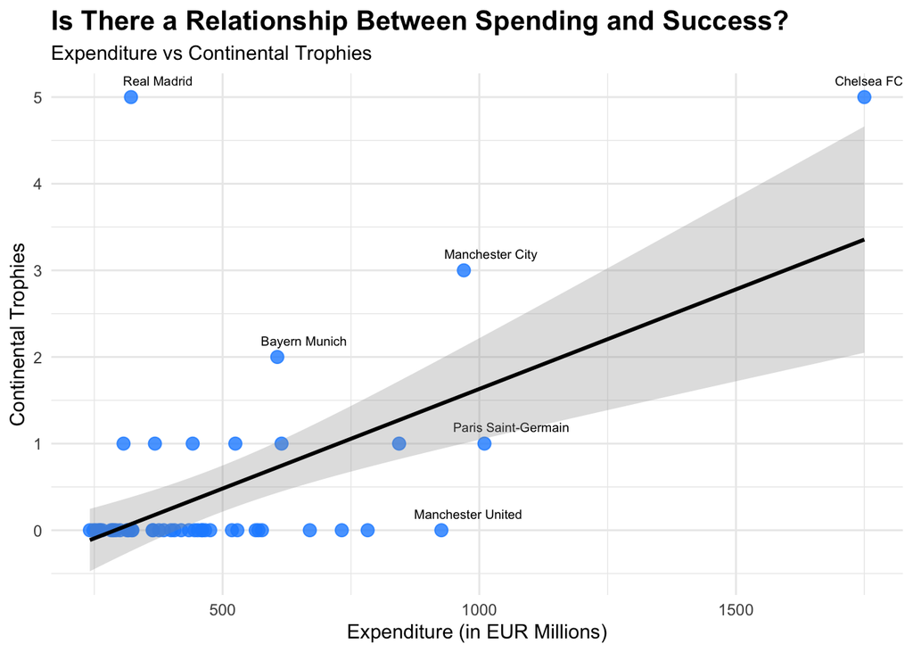

This visualization examines the relationship between club expenditure and continental success by plotting total spending against the number of trophies won. The use of a simple scatterplot with a fitted trend line allows the overall pattern to be immediately visible, reflecting the goal of clearly conveying the main relationship at the center of this analysis. The light grey smoothing band around the trend line represents the variability in outcomes, highlighting that while a general upward trend exists, there is significant dispersion around it. Clubs that invest more tend to achieve stronger outcomes, but this relationship is not absolute, as several high-spending clubs fail to win major trophies while some lower-spending clubs still achieve success.

Key clubs are labeled to emphasize deviations from the trend. Manchester United stands out as the highest-spending club without success, while Paris Saint-Germain has spent heavily with limited returns. In contrast, Bayern Munich and Manchester City represent high-spending clubs that have converted investment into multiple trophies, while Chelsea and Real Madrid emerge as clear outliers, achieving exceptional success, despite being at opposite ends of the expenditure range. These highlighted cases reinforce the idea that although financial investment plays a significant role, it does not fully determine success on its own.

To better understand how spending influences outcomes, this leads us into an exploration of how success varies across different spending levels.

## Vizualization 2: Success Across Spending Levels

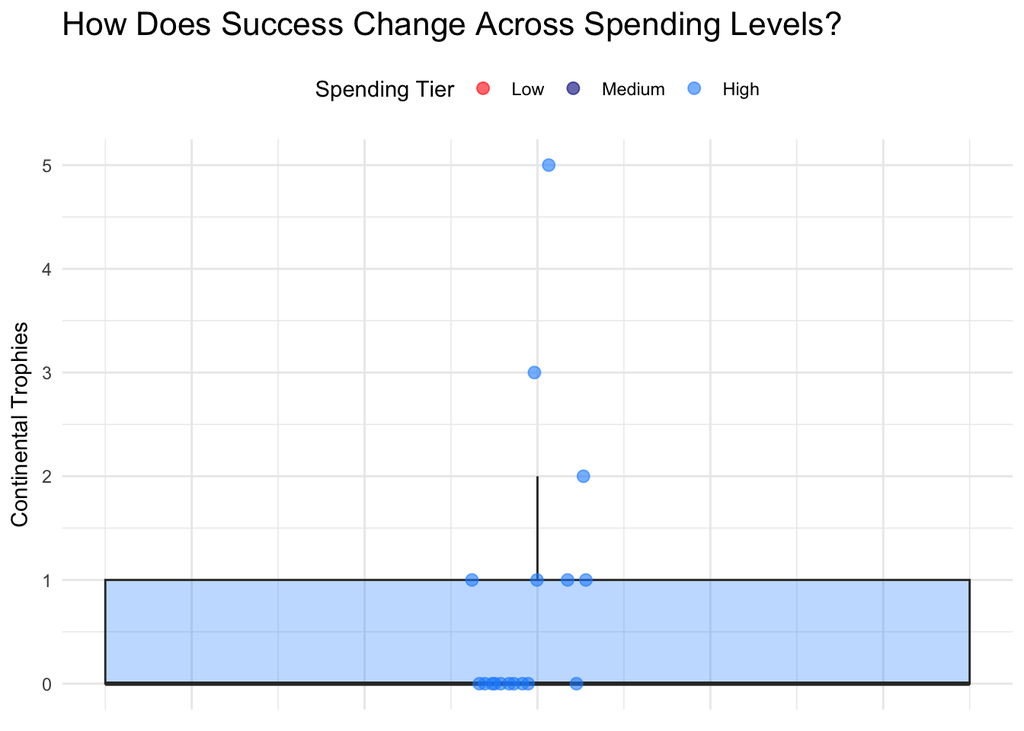

This visualization builds on the initial relationship by grouping clubs into spending tiers and examining how success is distributed within each level. Expenditure levels are determined by dividing clubs into the lowest, middle, and highest thirds of total spending. Shifting from individual data points to grouped categories, the plot highlights not only differences in average performance, but also the consistency of outcomes across spending levels. Higher spending tiers generally show greater levels of success, but also reveal variation within the group, as not all high-spending clubs achieve the same results. In contrast, lower spending tiers tend to cluster more tightly around lower trophy counts, indicating more consistently limited success.

The use of an animated boxplot allows each spending tier to be viewed sequentially, creating the effect of comparing distributions in a visual frame, making it easier to identify how predictable success is within each tier. This reinforces our idea that while higher spending increases the likelihood of success, it does not guarantee it, as variability remains even among the top spenders.

Building on this, our next visualization leads us into geographic context to examine how these patterns differ across countries and leagues.

## Vizualization 3: Spending Tiers Across Countries

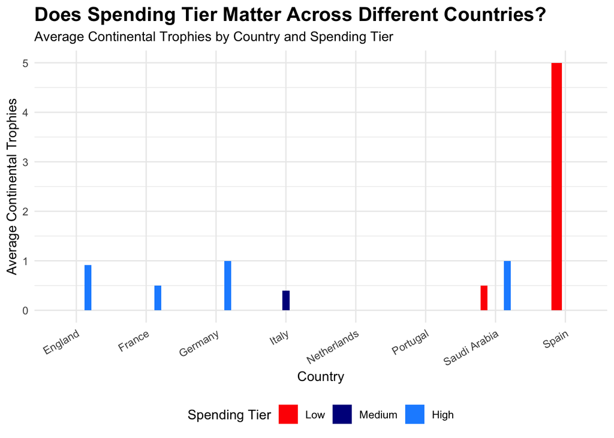

Here, we extend the analysis by introducing geographic context, examining how the relationship between spending and success varies across different countries. By grouping clubs by country while maintaining the structure of spending tiers, the plot highlights how similar levels of financial investment can produce different outcomes depending on the competitive environment.

While higher spending continues to be associated with greater success overall, the results are not the same across all countries. Some leagues show stronger conversion of spending into trophies, while others display greater variability or much weaker returns. This suggests that factors such as league competitiveness, distribution of talent, and structural differences between football systems may influence how effectively spending translates into success.

The use of grouped visual comparisons allows these cross country differences to be observed clearly without losing the underlying spending framework established in earlier figures. This reinforces the idea that financial investment operates within a broader context. In some cases, such as Spain, differences in financial structures and regulatory environments may influence how clubs allocate resources, leading to alternative approaches to achieving success beyond simply increasing expenditure.

More specifically, most countries that achieve consistent success tend to do so within the high spending tier, reinforcing the overall importance of financial investment. However, there are notable exceptions. Italy shows instances of success within the medium spending tier being the only country to find success in that tier, while Saudi Arabia demonstrates some success across both lower and higher tiers. Spain stands out as a particularly interesting case, achieving high levels of success despite the presence of clubs in lower spending tiers. This further emphasize that while money is important, it does not act as a universal predictor of success across all contexts.

Building on this, the next visualization explores whether consistent patterns in the relationship between spending and success emerge within individual countries.

## Vizualization 4: Patterns by Country

Shiny applications not supported in static R Markdown documents

In addition, the visualization introduces a toggle that allows users to switch between two distinct views: a scatterplot with a regression line, and a density plot. The scatterplot highlights the strength and direction of the relationship between expenditure and success, while the density plot shifts focus to the distribution of outcomes, showing how success is concentrated across spending tiers. This design allows users to approach the data from both a relational and distributional perspective.

Through this interactivity, it becomes clear to us that the impact of financial investment varies depending on the country. The density view shows that success is generally more concentrated within higher spending tiers, but the extent of this concentration differs across countries. This variation highlights that while higher spending often increases the likelihood of success, its effectiveness is influenced by the specific context of each football system. The scatterplot view further reveals a general positive trend when all countries are considered together, although the strength of this relationship varies across countries, with some exhibiting much stronger associations between expenditure and trophies than others.

From this, we shift focus to structural advantages at the club level, examining how historical status influences the relationship between spending and success.

## Vizualization 5: The Role of Club History

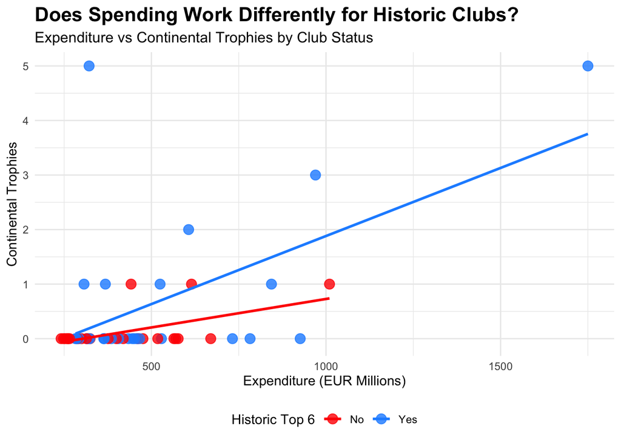

While this factor may not appear immediately important to casual fans, historical status plays a crucial role in shaping football success. It is not simply about a club relying on its past achievements, but rather the structural advantages that come with long term presence. Historically significant clubs tend to attract top players, draw in young talent through their academies and maintain huge dedicated fanbases, and develop strong internal club culture, all of which contribute to sustained success. In this analysis, a “historical Top 6” club is defined as one that ranks among the top six teams in all-time league point totals within its respective league.

This visualization builds on the previous analysis by introducing historical status as a key factor in understanding how spending translates into success. By separating clubs based on whether they are considered part of the historical “Top 6” of their respective leagues, the plot highlights differences in how effectively financial investment is converted into continental trophies.

While higher spending remains positively associated with success for both groups, a clear distinction emerges between historically established clubs and those that are not. Clubs classified within the Top 6 tend to achieve greater success at similar levels of expenditure, indicating that they are more efficient in converting financial resources into trophies. In contrast, non-historic clubs often require higher levels of spending to achieve comparable outcomes, and in many cases fail to do so.

The use of separate regression lines allows for a direct comparison between these two groups, making the difference in conversion efficiency visually apparent. This reinforces the idea that structural advantages, such as established infrastructure and global reputation play a significant role in shaping outcomes beyond financial investment alone.

To build on from this, the next visualization introduces another often overlooked factor: squad stability.

## Vizualization 6: Why Stability Matters

[figure not shown]

The stability of a squad reveals important information about how a club operates. When clubs retain players over longer periods, this promotes team cohesion and creates a more stable environment, which contributes to long-term success. This visualization builds on the previous findings by introducing squad stability, measured through player turnover, as an additional factor influencing how spending translates into success. The plot highlights how turnover, alongside spending tiers, affects club performance.

The data shows that all observed clubs have turnover levels above 100, with most falling below 400 and only 3 exceeding this range. While this represents a broad spectrum, it suggests that clubs generally operate within a moderately stable range. Despite large differences in expenditure, turnover levels remain relatively similar across clubs.

This indicates that successful clubs can exist across different levels of stability, raising the question of why turnover remains relatively consistent even when spending varies significantly. This observation motivates the next stage of the analysis, which focuses on how clubs allocate their spending through different recruitment strategies.

## Vizualization 7: The Difference That Recruitment Strategy Makes

Shiny applications not supported in static R Markdown documents

Rather than treating spending as a single quantity, this approach provides insight into the decision-making process behind financial investment. Recruitment levels are determined by dividing total expenditure by number of incoming transfers, and then grouping clubs into the lowest, middle, and highest thirds of average value spent per player. Clubs with higher spending per player tend to adopt a more concentrated recruitment strategy, while those with lower values reflect a broader, more distributed approach. The results suggest that recruitment strategy plays a meaningful role in shaping success, as different approaches produce varying outcomes even among clubs with similar overall expenditure.

The interactive features allow users to compare recruitment strategies directly, while also examining how patterns change when including or excluding relegated clubs. This provides a way to control for underperforming teams and better isolate whether certain recruitment approaches are associated with stronger outcomes. Through this, it becomes evident that success is not solely dependent on spending levels, but also on how effectively that spending is allocated across players.The results suggest that clubs adopting a more volume-based recruitment approach tend to achieve higher levels of success overall, while more balanced and concentrated strategies produce more mixed outcomes. Among relegated clubs, successful cases are limited and are more often associated with concentrated spending approaches.

An additional interactive feature allows users to switch view modes, introducing an alternative perspective that displays the proportion of successful clubs across each recruitment tier. This reinforces the earlier observation, as the volume-based approach shows the highest success rate, exceeding that of elite buyers, while the balanced approach shows little to no success within our observed sample.

This ultimately leads into the final visualization, which brings all identified factors together to provide a comprehensive view of what drives success.

## Vizualization 8: The Drivers of Success

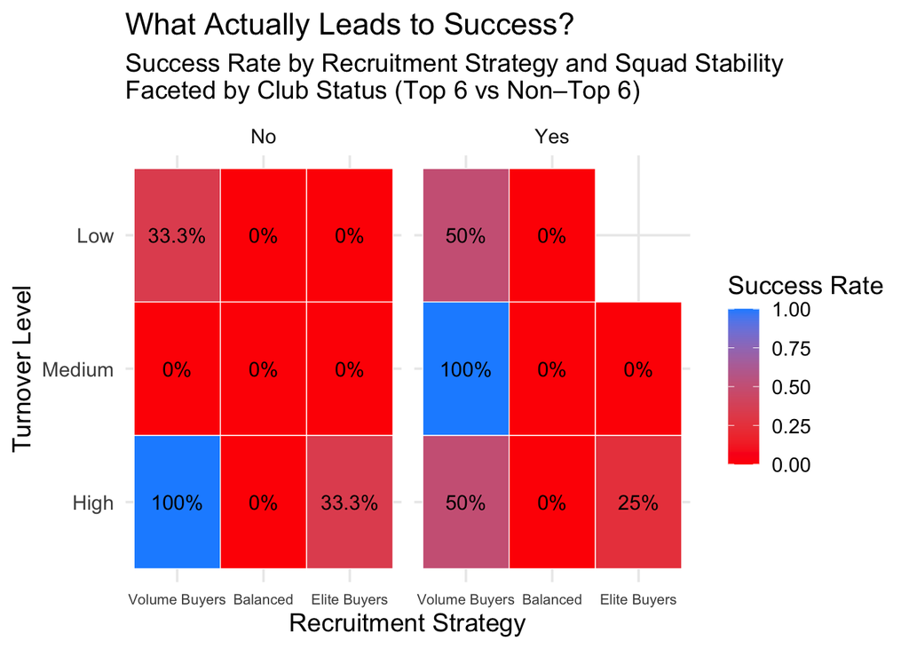

This final visualization brings together all of the factors explored throughout the analysis, combining spending, recruitment strategy, squad stability, and historical status into a single framework. Rather than examining these variables in isolation, it highlights how they all interact to shape success in the modern game.

The plot reveals that success is most consistently observed when multiple favorable conditions are met simultaneously. In many cases, volume buyers see the most success, for historically significant clubs this is true at all turnover levels, and especially in moderate turnover ranges. However, for historically insignificant clubs, it is low and high turnover where success is concentrated. When one or more of these elements is missing, the likelihood of success decreases, even in cases of high financial investment.

By presenting these relationships in a unified structure, the visualization makes it clear that no single factor is sufficient on its own. Instead, success emerges from the interaction between financial resources, decision-making, and organizational stability. This helps explain why clubs with similar spending levels can experience very different outcomes, as their underlying structures and strategies differ.

Overall, this reinforces the central argument of my analysis: although money plays a critical role in football success, it is not the sole determinant. Instead, success is best understood as the result of how numerous factors come into play together. Financial investment is combined with recruitment strategy, squad stability, and structural advantages.

## Conclusion: The Real Key to Success

This analysis set out to examine whether money is truly the key to success in modern football. While the results consistently show that higher spending is associated with greater success, the relationship is far from absolute. Across the visualizations, it becomes clear that factors such as historical status, squad stability, and recruitment strategy all play critical roles in determining outcomes. Clubs that are able to combine financial investment with effective decision-making and strong organizational structure are far more likely to achieve sustained success.

Football success cannot be reduced to spending alone. It is the result of how multiple factors interact over time, shaping both short-term performance and long-term achievement. As such, there is no single key to success in football.